# Bayesian Modelling

Brian R. Bolivar A. - Cristina Farruku

2022-07-03

```r
data <- read.csv(file="diamonds.csv", header = T)
colnames(data)[10] <- "y.m"
knitr::kable(head(data),align = "cccccccccc", "pipe")
```

| X | carat | cut | color | clarity | depth | table | price | x | y.m | z |
| --- | --- | --- | --- | --- | --- | --- | --- | --- | --- | --- |
| 1 | 0.23 | Ideal | E | SI2 | 61.5 | 55 | 326 | 3.95 | 3.98 | 2.43 |
| 2 | 0.21 | Premium | E | SI1 | 59.8 | 61 | 326 | 3.89 | 3.84 | 2.31 |
| 3 | 0.23 | Good | E | VS1 | 56.9 | 65 | 327 | 4.05 | 4.07 | 2.31 |
| 4 | 0.29 | Premium | I | VS2 | 62.4 | 58 | 334 | 4.20 | 4.23 | 2.63 |
| 5 | 0.31 | Good | J | SI2 | 63.3 | 58 | 335 | 4.34 | 4.35 | 2.75 |
| 6 | 0.24 | Very Good | J | VVS2 | 62.8 | 57 | 336 | 3.94 | 3.96 | 2.48 |

# Variables

## Numerical Variables

- **carat**: weight of the diamond;
- **x**: length in mm;
- **y**: width in mm;
- **z**: dept in mm;
- **depth**: total depth percentage, measured as: $\frac{z}{mean(x,y)}=\frac{2\ z}{x+y}$;
- **table**: a diamond’s table refers to the flat facet of the diamond seen when the stone is face up. The main purpose of a diamond table is to refract entering light rays and allow reflected light rays from within the diamond to meet the observer’s eye;
- **price**: the price of the diamond (range 326 - 18.823 in $);

## Categorical Variables

- **cut**: quality of the cut ( Fair, Good, Very Good, Premium, Ideal);
- **color**: color of the diamond ( D being the best and J the worst);
- **clarity**: a measurement of how the diamonds is (l1 as the worst and IF as the best);

# Initial Data Analysis | Full Data-set

## Missing Values:

```r
summary(data)
```

```
##        X             carat            cut               color
##  Min.   :    1   Min.   :0.2000   Length:53940       Length:53940
##  1st Qu.:13486   1st Qu.:0.4000   Class :character   Class :character
##  Median :26971   Median :0.7000   Mode  :character   Mode  :character
##  Mean   :26971   Mean   :0.7979
##  3rd Qu.:40455   3rd Qu.:1.0400
##  Max.   :53940   Max.   :5.0100
##    clarity              depth           table           price
##  Length:53940       Min.   :43.00   Min.   :43.00   Min.   :  326
##  Class :character   1st Qu.:61.00   1st Qu.:56.00   1st Qu.:  950
##  Mode  :character   Median :61.80   Median :57.00   Median : 2401
##                     Mean   :61.75   Mean   :57.46   Mean   : 3933
##                     3rd Qu.:62.50   3rd Qu.:59.00   3rd Qu.: 5324
##                     Max.   :79.00   Max.   :95.00   Max.   :18823
##        x               y.m               z
##  Min.   : 0.000   Min.   : 0.000   Min.   : 0.000
##  1st Qu.: 4.710   1st Qu.: 4.720   1st Qu.: 2.910
##  Median : 5.700   Median : 5.710   Median : 3.530
##  Mean   : 5.731   Mean   : 5.735   Mean   : 3.539
##  3rd Qu.: 6.540   3rd Qu.: 6.540   3rd Qu.: 4.040
##  Max.   :10.740   Max.   :58.900   Max.   :31.800
```

```r
library(dplyr)
data <- filter(data, data$z > 0)    # Remove rows with x, y, z = 0
```

From the summary of the data we can see that variables “x”, “y.m” and “z”, which represent the dimensions of the diamonds, have values equal to 0. Considered the numbers of observation we prefer to remove the rows with this values.

## Correlation Plot

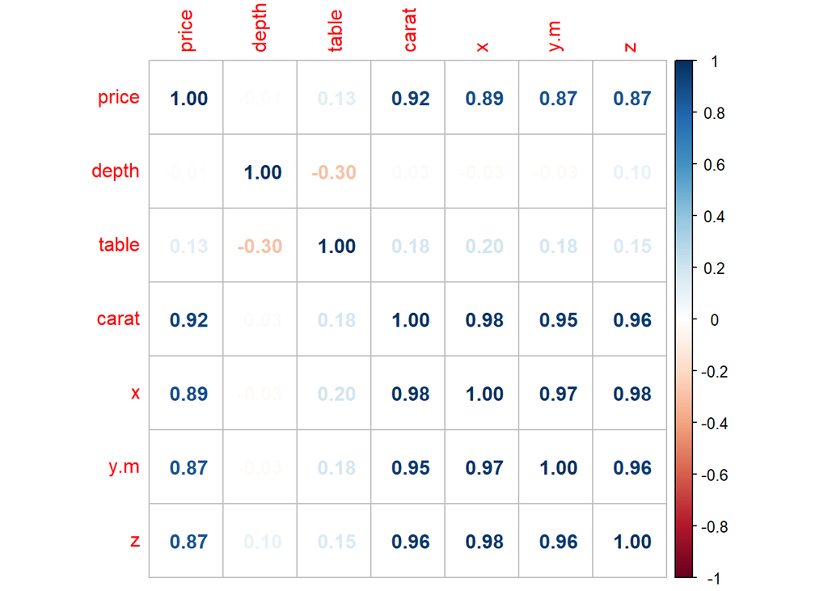

```r
numerical.data <- data[c(8, 6, 7, 2, 9, 10, 11 )]
M = cor(numerical.data)
corrplot(M, method = 'number')
```

From the Correlation-Plot:

- Price Variable: this variables have high correlation with “carat” and the 3-dimensions of the diamond;
- There is high correlation between “carat” and the 3-dimensions of the diamond, an explanation can be due to the proportion of the dimension of the diamonds and consequently the carat (weight) of the same.

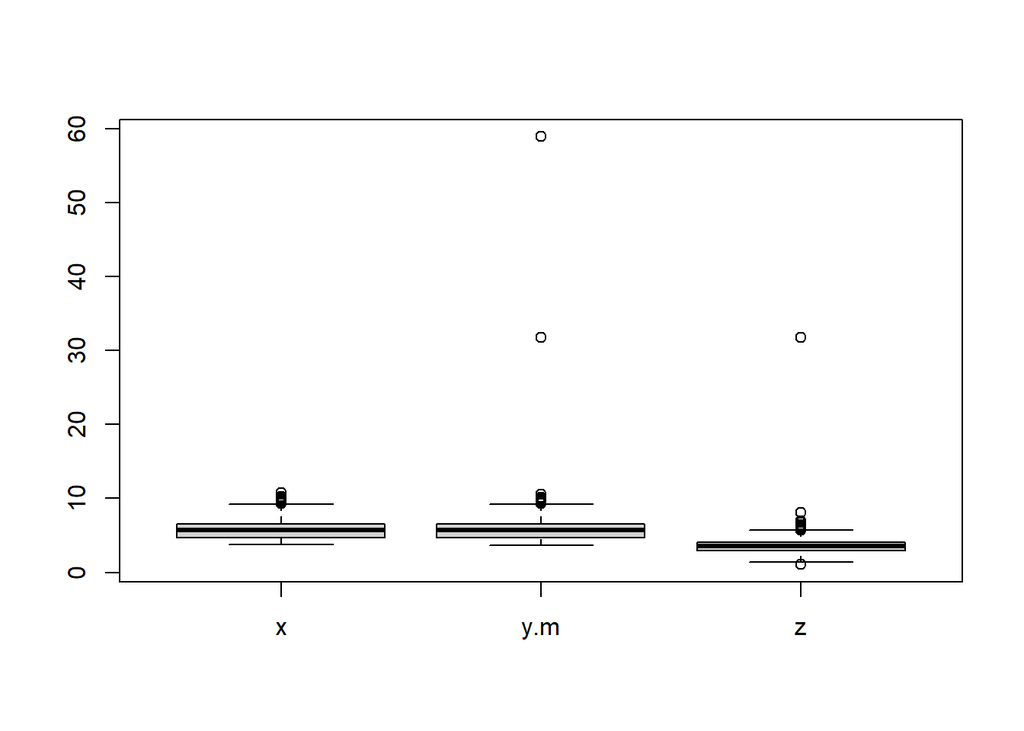

```r
boxplot(numerical.data[c(5, 6, 7)])
```

Considering the number of the observation we prefer to keep the outliers.

# Initial Analysis | Train-Set

```r
set.seed(1)
subsample <- sample(1:nrow(data), size = 4000, replace = FALSE)

train <- data[subsample[1:3000],]
test <- data[subsample[3001:4000],]
```

We’re considering a sub-set of 4000 observations, 3000 for the train and 1000 for the test.

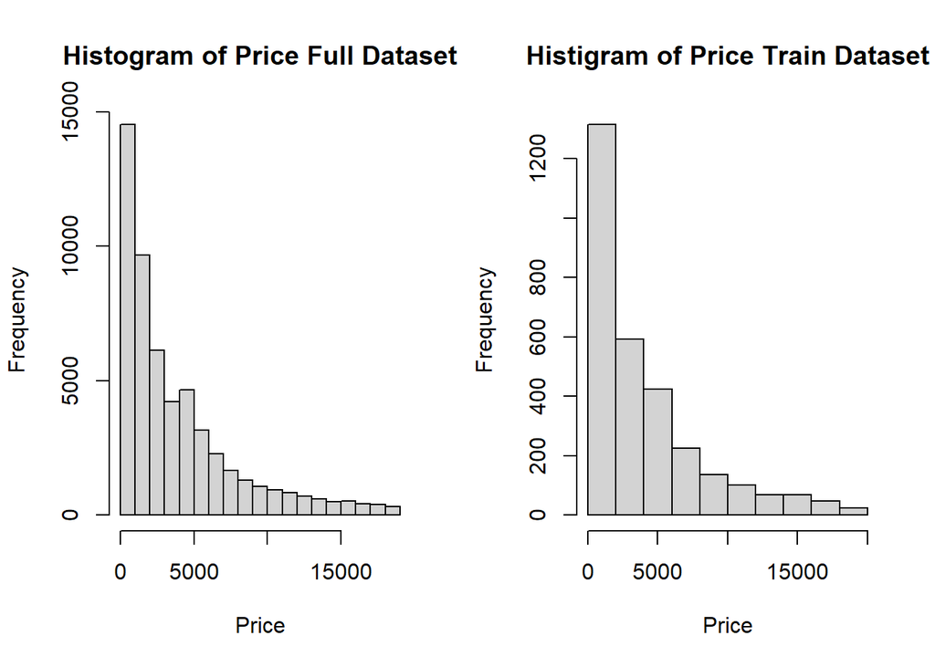

```r
par(mfrow=c(1,2))
hist(data$price, main=c("Histogram of Price Full Dataset"), xlab = c("Price"))
hist(train$price, main=c("Histigram of Price Train Dataset"), xlab = c("Price"))
```

The Price of the Train-Set has the same distribution of the Price of the Full-Set.

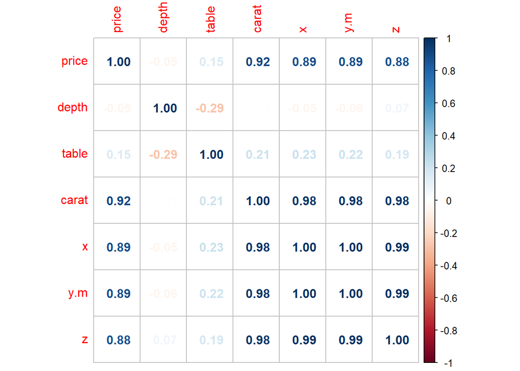

```r
numerical.data <- train[c(8, 6, 7, 2, 9, 10, 11 )]
M = cor(numerical.data)
corrplot(M, method = 'number')
```

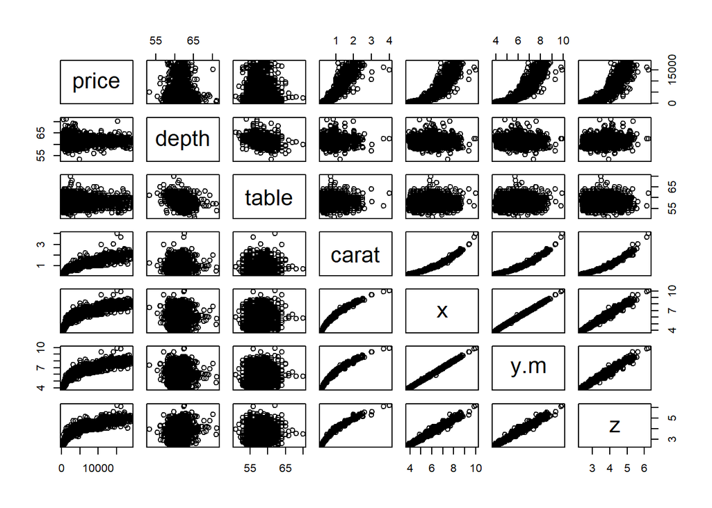

```r
plot(numerical.data)
```

Same conclusion for the Tran-Set, covariates have the same behavior of the covariates of the Full-Set.

## Categorical Variables Analysis

### Categorical and Price

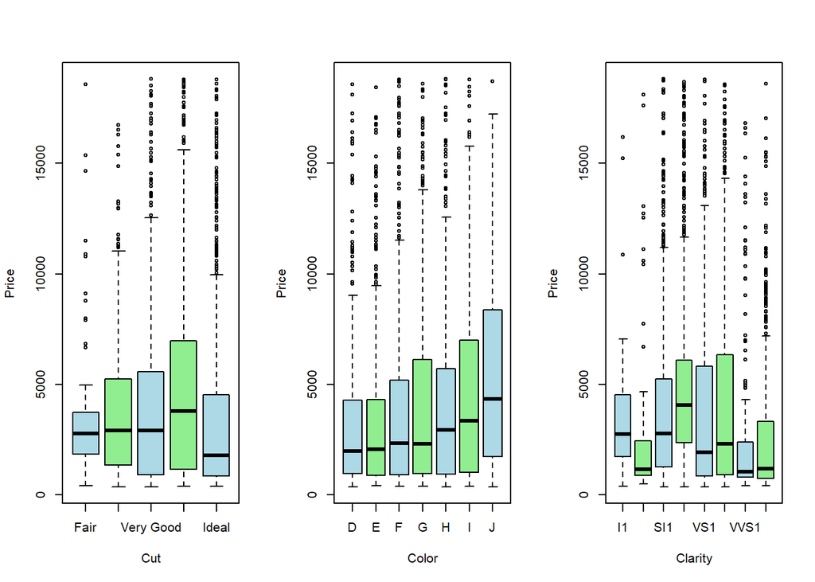

```r
par(mfrow=c(1,3))

mycolor=c("lightblue", "lightgreen")

train$cut <- factor(train$cut , levels=c("Fair", "Good", "Very Good", "Premium", "Ideal"))
boxplot(train$price ~ train$cut, ylab="Price", xlab="Cut", col=mycolor)
boxplot(train$price ~ train$color, ylab="Price", xlab="Color", col=mycolor)
boxplot(train$price ~ train$clarity, ylab="Price", xlab="Clarity", col=mycolor)
```

### Categorical and Carat

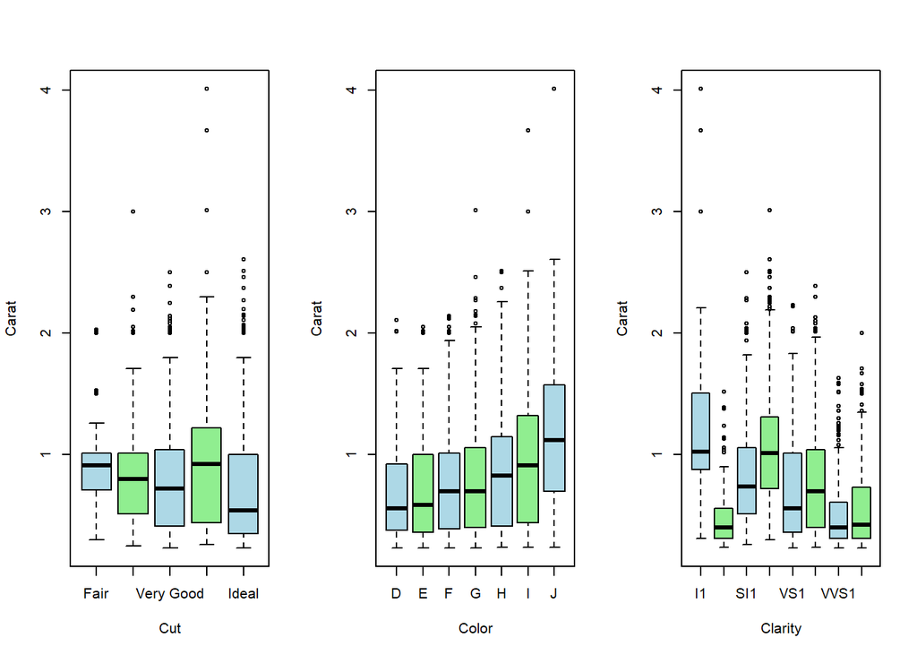

```r
par(mfrow=c(1,3))
boxplot(train$carat ~ train$cut, ylab="Carat", xlab="Cut", col=mycolor)
boxplot(train$carat ~ train$color, ylab="Carat", xlab="Color", col=mycolor)
boxplot(train$carat ~ train$clarity, ylab="Carat", xlab="Clarity", col=mycolor)
```

### Categorical and Table

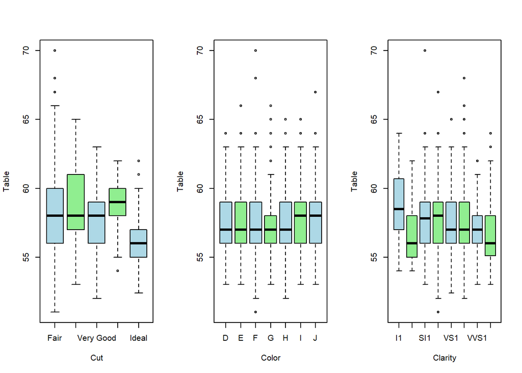

```r
par(mfrow=c(1,3))
boxplot(train$table ~ train$cut, ylab="Table", xlab="Cut",col=mycolor)
boxplot(train$table ~ train$color, ylab="Table", xlab="Color", col=mycolor)
boxplot(train$table ~ train$clarity, ylab="Table", xlab="Clarity", col=mycolor)
```

It seems there is not correlation with Table variable.

### Categorical and Depth

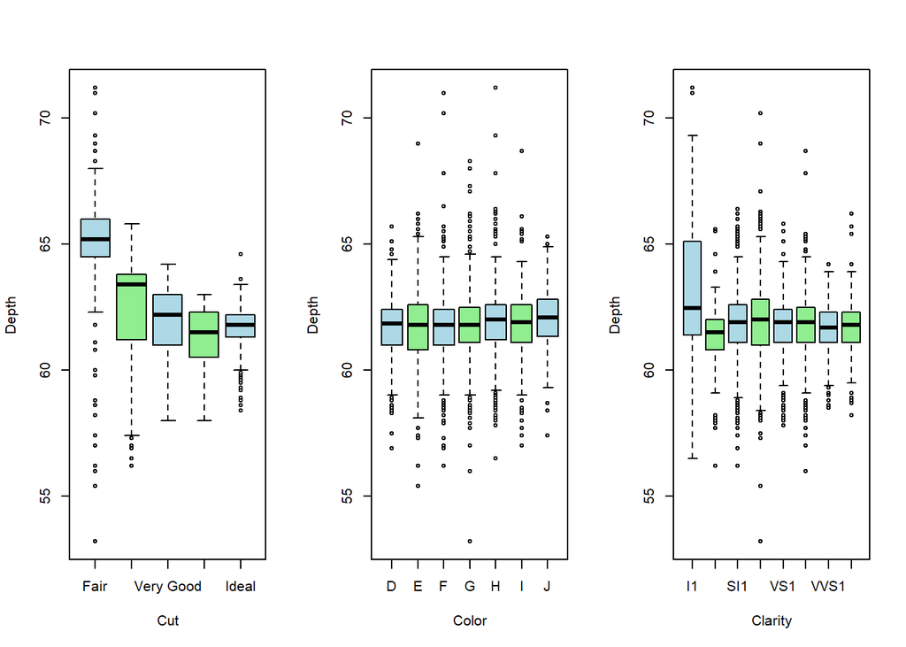

```r
par(mfrow=c(1,3))
boxplot(train$depth ~ train$cut, ylab="Depth", xlab="Cut", col=mycolor)
boxplot(train$depth ~ train$color, ylab="Depth", xlab="Color", col=mycolor)
boxplot(train$depth ~ train$clarity, ylab="Depth", xlab="Clarity", col=mycolor)
```

We can see only a negative correlation with the cut of the diamonds.

### Categorical and Length in mm

For the last box-plot we’re considering only the values of $x$.

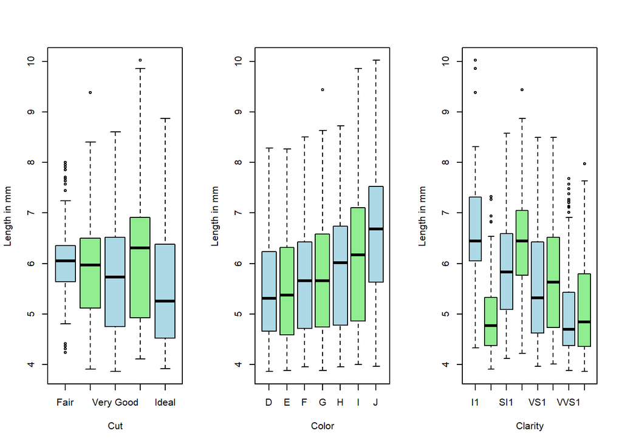

```r
par(mfrow=c(1,3))
boxplot(train$x ~ train$cut, ylab="Length in mm", xlab="Cut", col=mycolor)
boxplot(train$x ~ train$color, ylab="Length in mm", xlab="Color", col=mycolor)
boxplot(train$x ~ train$clarity, ylab="Length in mm", xlab="Clarity", col=mycolor)
```

It seems we have:

1. Positive correlation with color;
2. A sort of negative correlation with clarity.

# Fitting Models

Now we consider a series of models to compare and see how they perform for prediction purpose.

```r
y <- train$price   # response
X_train <- train[, c(2, 3, 4, 5, 6, 7, 9, 10, 11)]  # In the covariates we have a variables which rapresent the index of the observation, we don't need it.

X_train <- model.matrix(y~. , data=X_train)  # Trasform the categorical variables in matrix with 0-1

n <- nrow(X_train)
p <- ncol(X_train)
```

## Bayesian Normal Linear Regression

The first model we consider is the Bayesian Normal Regression, we don’t expect a great performance of this one, but we’re going to use it to compare with others models with better performance.

The model is defined as:

$$Y=\beta_0+\beta_1+x_i+...+\beta_px_p$$

where $p$ is the number of predictors.

And $Y_i$ is defined as:

$$Y_i|\beta,\tau
\sim \mathcal{N}(\beta^Tx_i, \tau)$$

Where $\tau = \frac{1}{\sigma ^2}$ (the precision)

Priors:
$$\beta_j \sim \mathcal{N}_p(0, 0.01)$$

The choice of the **hyper-parameters** was made to have:

- Weak-Informative prior for $\beta$;
- Non-Informative prior for $\tau$.

### Algorithm

```r
model1_code <- function() {
  ## Likelihood
  for (i in 1:n) {
    y[i] ~ dnorm(mu[i], tau)
    mu[i] <- X[i,] %*% b[]
  }
  ## Priors
  for (j in 1:p) {
    b[j] ~ dnorm(0, 0.01)
  }
  tau <- pow(sigma, -2)  # reciprocal of the variance
  sigma ~ dunif(0,10^6)  # range of values (non informative), we always be
                         # in this range also in the posteriori
                         # Important limit in the definition of the possible range of the standard deviation
}

model1_data <- list(y = y, X = X_train, n = n, p = p)
model1_params <- c("b", "mu", "tau")

model1_run <- jags(
  data = model1_data,
  parameters.to.save = model1_params,
  model.file = model1_code,
  n.chains = 1,
  n.iter = 5000,
  n.burnin = 2000,
  n.thin = 1,
  jags.seed = 101
)
```

```
## module glm loaded
```

### Diagnostic

Before using the MCMC output for posterior inference we need to check that the resulting chain provide a appropriate approximation of the true posterior distribution.

#### MCMC Traceplot

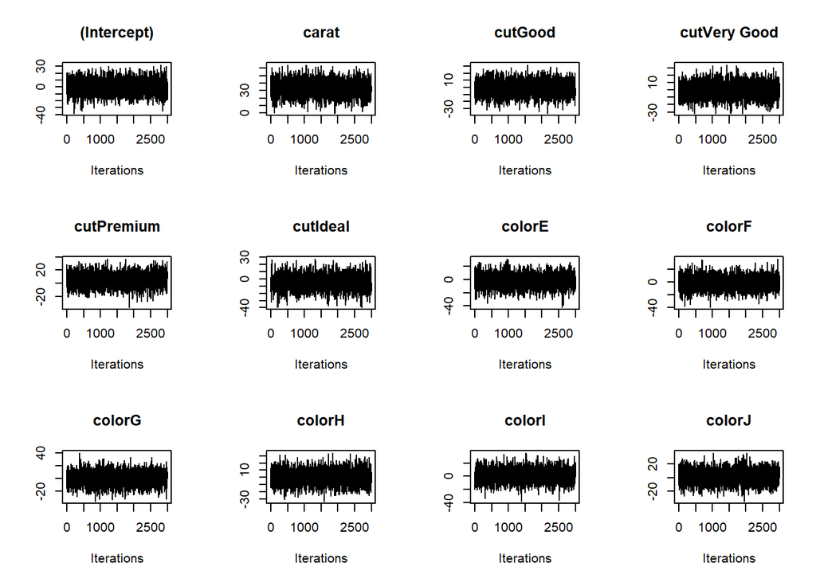

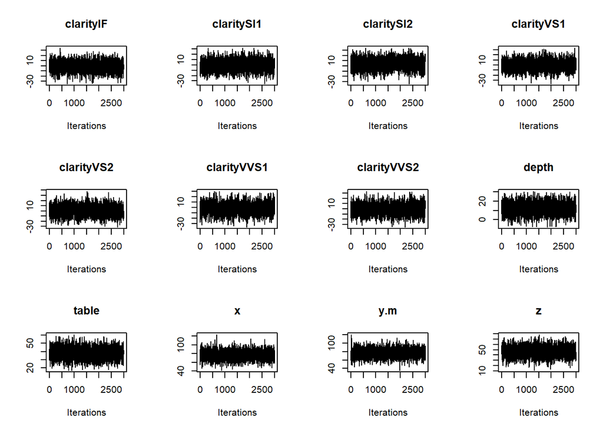

```r
par(mfrow=c(3, 4))
for(i in 1:p){
coda::traceplot(mcmc(model1_run$BUGSoutput$sims.list$b[,i]), main=colnames(X_train)[i])
}
```

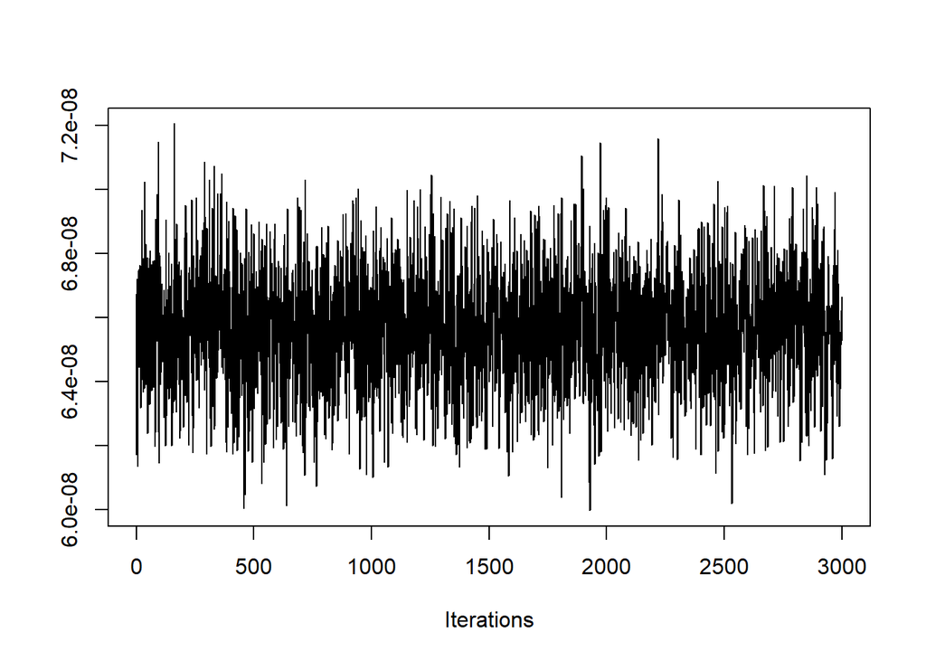

```r
traceplot(mcmc(model1_run$BUGSoutput$sims.list$tau))
```

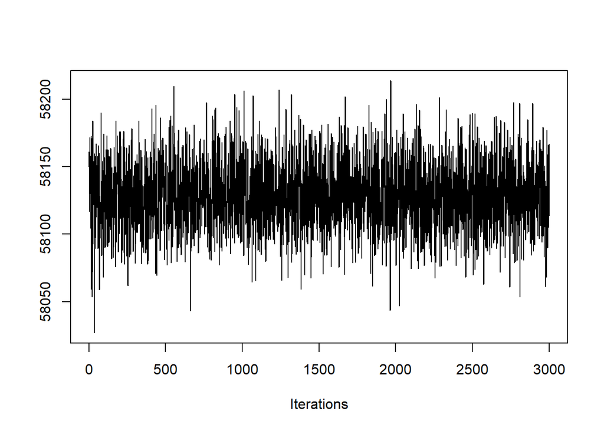

```r
traceplot(mcmc(model1_run$BUGSoutput$sims.list$deviance))
```

No pattern and autocorrelation is detected by the trace-plots.

#### Auto-Correlation Plot

We don’t want dependencies in the chain, these in a Markov chain can be measured using autocorrelation.

Autocorrelation of order (lag):

$$acf_k(\theta) = \frac{\frac{1}{S-k}
\sum^{S-k}_{s=1}(\theta^{(s)}-\bar\theta)(\theta^{(s+k)}-\bar\theta)}{\frac{1}{S-k}\sum^{S-k}_{s=1}(\theta^{(s)}-\bar\theta)^2}$$

$$\bar\theta=\frac{1}{S-k}\sum^{S-k}_{s-1}$$

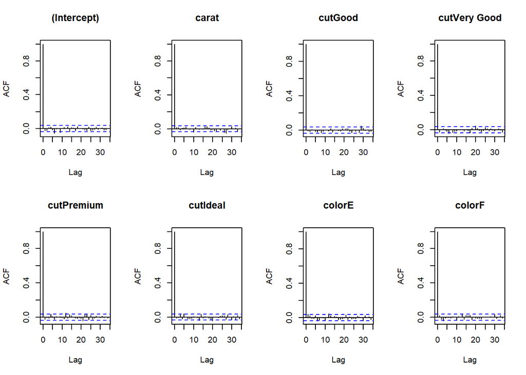

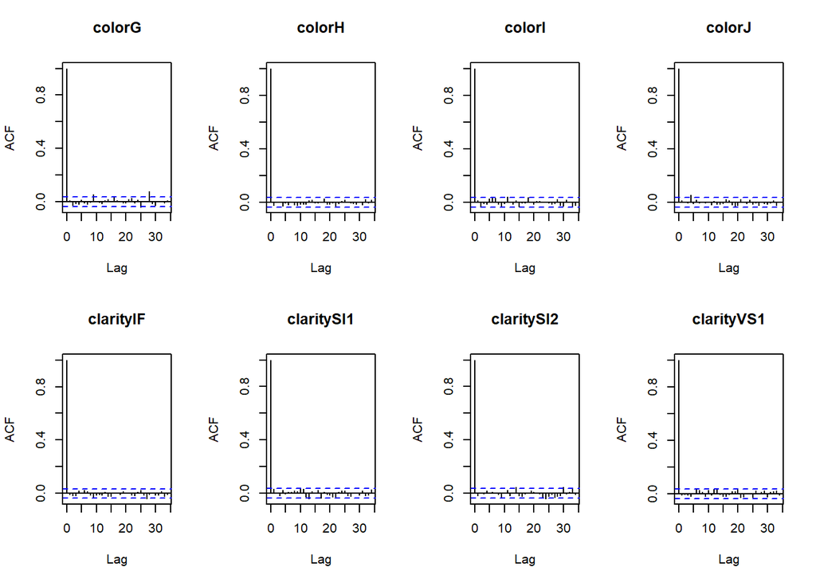

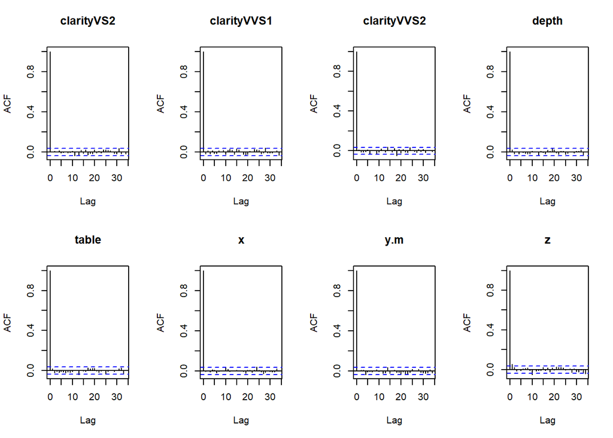

```r
par(mfrow=c(2,4))
for(i in 1:p){
acf(model1_run$BUGSoutput$sims.list$b[,i], main=colnames(X_train)[i])
}
```

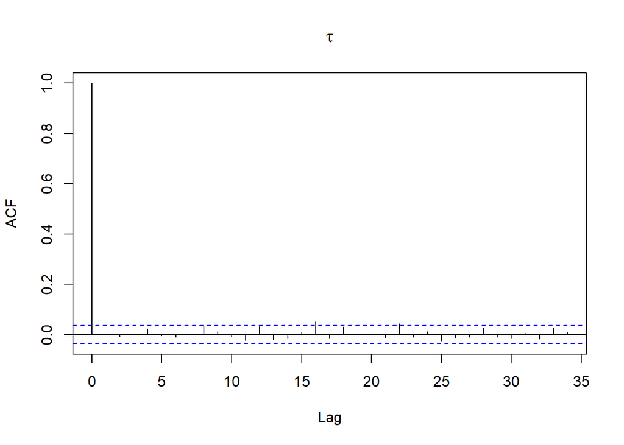

```r
acf(model1_run$BUGSoutput$sims.list$tau, main=expression(tau))
```

There’s not detected high values of acf.

#### Effective Sample Size

ESS:

$$ESS= \frac{G}{1+2\sum^G_{g=1} acf_g}$$

with G: the number of the post burn-in MCMC samples.

```r
for(i in 1:p){
  cat(colnames(X_train)[i],": ",coda::effectiveSize(mcmc(model1_run$BUGSoutput$sims.list$b[,i])), sep="", end="\n")
}
```

```
## (Intercept): 3517.5
## carat: 3000
## cutGood: 3000
## cutVery Good: 3179.374
## cutPremium: 3000
## cutIdeal: 3000
## colorE: 2770.668
## colorF: 3296.986
## colorG: 3000
## colorH: 3000
## colorI: 2659.214
## colorJ: 2584.626
## clarityIF: 3000
## claritySI1: 2825.429
## claritySI2: 3000
## clarityVS1: 3000
## clarityVS2: 3000
## clarityVVS1: 3000
## clarityVVS2: 3000
## depth: 3000
## table: 3000
## x: 3000
## y.m: 3000
## z: 2679.918
```

```r
 cat("tau ESS:",coda::effectiveSize(mcmc(model1_run$BUGSoutput$sims.list$tau)^-1))
```

```
## tau ESS: 3000
```

#### Geweke Test

Consider two “windows” of the chain:

- The initial %x: $\theta_l$
- The Last y%:$\theta_L$

If the chain is stationaty, the teo corresponding sample means $\bar\theta_l$ and $\bar\theta_L$ should be equal.

The Geweke statistic is :

$$Z_n=\frac{\bar\theta_l-\bar\theta_L}{\sqrt{\hat s_l^2+\hat s^2_L}}
\rightarrow \mathcal {N}(0,1)$$

If $|Z_n| >1.96$ the hypothesis of the stationary is rejected.

```r
for(i in 1:p){
cat('Geweke test for ',colnames(X_train)[i],':',coda::geweke.diag(
model1_run$BUGSoutput$sims.list$b[,i])$z,end="\n")
}
```

```
## Geweke test for  (Intercept) : -0.3699547
## Geweke test for  carat : -0.945198
## Geweke test for  cutGood : -0.3661099
## Geweke test for  cutVery Good : -1.052134
## Geweke test for  cutPremium : -0.6634566
## Geweke test for  cutIdeal : -0.1738825
## Geweke test for  colorE : -0.1210406
## Geweke test for  colorF : 0.2047067
## Geweke test for  colorG : -0.8215438
## Geweke test for  colorH : 0.3977761
## Geweke test for  colorI : -0.6267364
## Geweke test for  colorJ : -0.6116152
## Geweke test for  clarityIF : 0.9907561
## Geweke test for  claritySI1 : -1.854017
## Geweke test for  claritySI2 : 0.434991
## Geweke test for  clarityVS1 : -1.046291
## Geweke test for  clarityVS2 : -1.380999
## Geweke test for  clarityVVS1 : 0.4338231
## Geweke test for  clarityVVS2 : 0.9429859
## Geweke test for  depth : 0.07992018
## Geweke test for  table : -0.2333437
## Geweke test for  x : 0.1984663
## Geweke test for  y.m : -0.6523163
## Geweke test for  z : 1.520926
```

```r
cat('Geweke test for Tau:',coda::geweke.diag(
model1_run$BUGSoutput$sims.list$tau^-1)$z)
```

```
## Geweke test for Tau: -0.5857924
```

## Parameters Analysis

### Significant Variables and Credible Intervals

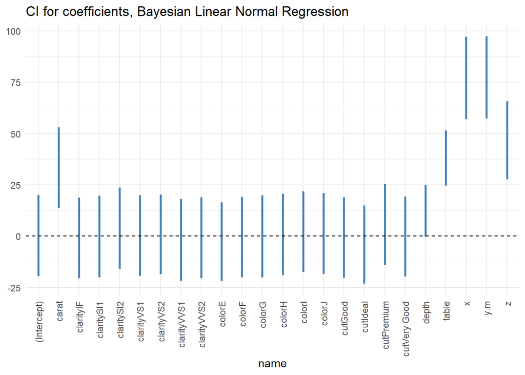

```r
b1_df <- as.data.frame(model1_run$BUGSoutput$sims.list$b)
names(b1_df) <- colnames(X_train)
b1_long <- pivot_longer(b1_df, cols = 1:24) %>%
  group_by(name) %>%
  summarise(q025 = quantile(value, 0.025), q975 = quantile(value, 0.975)) %>%
  ungroup()

ggplot(b1_long, aes(x = name, ymin = q025, ymax = q975)) +
  geom_linerange(size = 1, color = "steelblue") +
  geom_hline(yintercept = 0, linetype = 2) + theme_minimal() +
  theme(axis.text.x = element_text(angle = 90, vjust = 0.5, hjust=1)) +
  ggtitle("CI for coefficients, Bayesian Linear Normal Regression")
```

```r
resu = as.matrix(colMeans(model1_run$BUGSoutput$sims.list$b),nrow=25)
resu = rbind(resu,colMeans(model1_run$BUGSoutput$sims.list$tau))
rownames(resu) = c(colnames(X_train),"Tau")
colnames(resu) = "Posterior Expectation"

res = t(apply(model1_run$BUGSoutput$sims.list$b,2,quantile,
prob=c(.025,.975)))
res = rbind(res,t(quantile(model1_run$BUGSoutput$sims.list$tau,
prob=c(.025,.975))))
rownames(res) = c(colnames(X_train),"Tau")
colnames(res) = c("2.5 % Quantile","97.5 % Quantile")
knitr::kable(cbind(res,resu), align = "ccc")
```

|  | 2.5 % Quantile | 97.5 % Quantile | Posterior Expectation |
| --- | --- | --- | --- |
| (Intercept) | -19.5372177 | 20.0579251 | 0.1877406 |
| carat | 13.6481562 | 52.8805761 | 33.5317136 |
| cutGood | -20.3651204 | 18.8942576 | -0.3772706 |
| cutVery Good | -19.8041908 | 19.2436953 | -0.0388490 |
| cutPremium | -14.0502967 | 25.2888780 | 5.0470704 |
| cutIdeal | -23.1314444 | 14.8289088 | -4.0359920 |
| colorE | -21.8463369 | 16.4260917 | -2.0123574 |
| colorF | -20.0639737 | 19.0128990 | -0.2863930 |
| colorG | -20.1325307 | 19.9064304 | 0.3436131 |
| colorH | -18.9026143 | 20.5126101 | 0.4525369 |
| colorI | -17.5204109 | 21.6950022 | 1.3588888 |
| colorJ | -18.4930219 | 21.0368458 | 1.4649037 |
| clarityIF | -20.4979946 | 18.6764798 | -0.8463640 |
| claritySI1 | -20.1115084 | 19.6415402 | -0.1764453 |
| claritySI2 | -16.0245963 | 23.6809647 | 4.1006121 |
| clarityVS1 | -19.2997219 | 19.8378689 | -0.0201296 |
| clarityVS2 | -18.5248083 | 20.1381654 | 0.4134135 |
| clarityVVS1 | -21.7987138 | 18.0620846 | -1.6999570 |
| clarityVVS2 | -20.4563016 | 18.9736724 | -1.3405591 |
| depth | -0.2441809 | 24.8991482 | 12.1682685 |
| table | 24.5791295 | 51.4089495 | 38.1472073 |
| x | 56.9788281 | 97.0566373 | 77.0809743 |
| y.m | 57.2858510 | 97.2223889 | 76.8179433 |
| z | 27.6489323 | 65.7880054 | 47.0559618 |
| Tau | 0.0000001 | 0.0000001 | 0.0000001 |

From the above result we notice that the majority of the credible intervals do include the zero, meaning that the parameter may not have significant impact on the response variable.

Now we just plot the distribution of significant variables with their CI and mean.

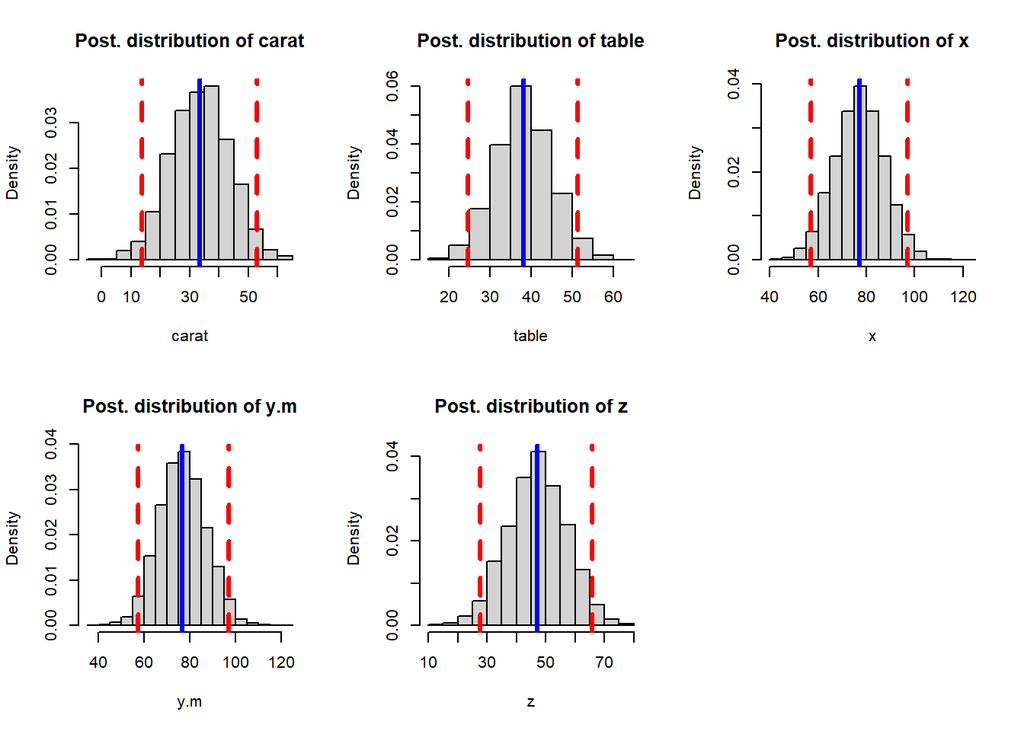

```r
par(mfrow=c(2,3))
for(i in c(2, 21, 22, 23, 24)){
hist(model1_run$BUGSoutput$sims.list$b[,i],
main=paste("Post. distribution of", rownames(res)[i]),
xlab = rownames(res)[i],cex=0.8, prob = TRUE)
abline(v=res[i,1], col="red",lty=2, lwd=3)
abline(v=res[i,2], col="red",lty=2, lwd=3)
abline(v=resu[i,1], col="blue", lwd=3)
}
```

### Posterior Predictive Model Checking

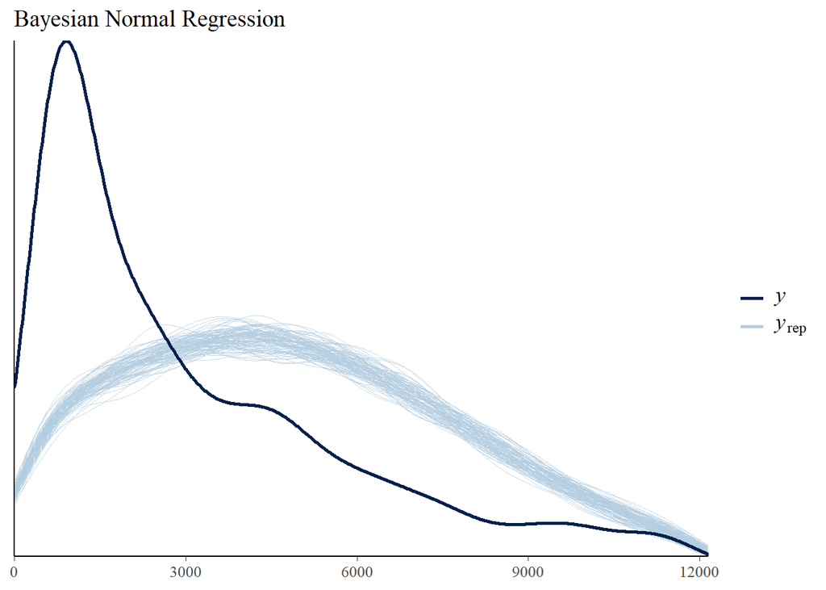

```r
mu1 <- model1_run$BUGSoutput$sims.list$mu
tau1 <- model1_run$BUGSoutput$sims.list$tau
yrep1 <- t(sapply(1:100, function(i) rnorm(n, mu1[i,], sqrt(1/tau1[i]))))

ppc_dens_overlay(y, yrep1) + ggtitle("Bayesian Normal Regression") + xlim(0, 10.5^4)
```

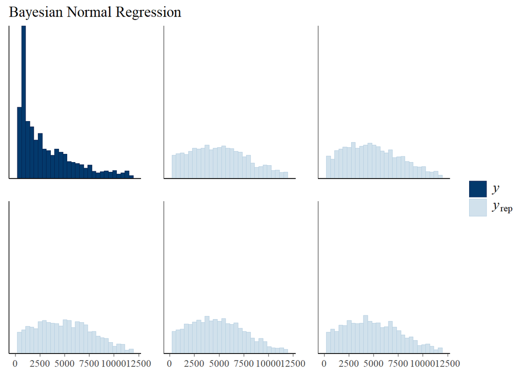

```r
ppc_hist(y, yrep1[1:5,]) + ggtitle("Bayesian Normal Regression") + xlim(0, 10.5^4)
```

The last result confirm what we think from the beginning, the Bayesian Normal Regression perform very bad for this analysis.

## Bayesian t-Student Regression

The next model we consider is the Bayesian t-Student Regression, the response is defined as:

$$Y_i|\mu_i, \sigma^2, k \sim t_k(\mu_i, \sigma^2)$$

and the model:

$$\mu_i=\beta_0+\beta_1x_i+...+\beta_px_p$$

and priors:

$$\sigma \sim U(0, 10^6)$$

$t_k$ is a non-central and scale t-distribution:

$$Y_i=\mu_i + \delta t_k$$

### Metropolis-Hastings Algorithm

```r
model2_code <- function() {
  ## Likelihood
  for (i in 1:n) {
    y[i] ~ dt(mu[i], tau, k)
    mu[i] <- X[i,] %*% b[]
  }
  ## Priors
  for (j in 1:p) {
    b[j] ~ dnorm(0, 0.01)
  }
  tau <- pow(sigma, -2)
  sigma ~ dunif(0,10^6)
  k ~ dgamma(0.04, 0.01)
}

model2_data <- list(y = y, X = X_train, n = n, p = p)
model2_params <- c("b", "mu", "tau", "k")

model2_run <- jags(
  data = model2_data,
  parameters.to.save = model2_params,
  model.file = model2_code,
  n.chains = 1,
  n.iter = 5000,
  n.burnin = 2000,
  n.thin = 1
)
```

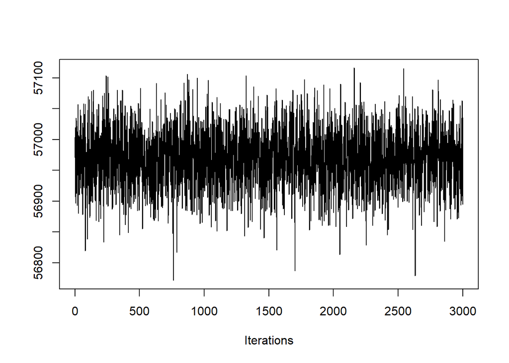

```r
traceplot(mcmc(model2_run$BUGSoutput$sims.list$deviance))
```

### Diagnostic

#### MCMC Traceplot

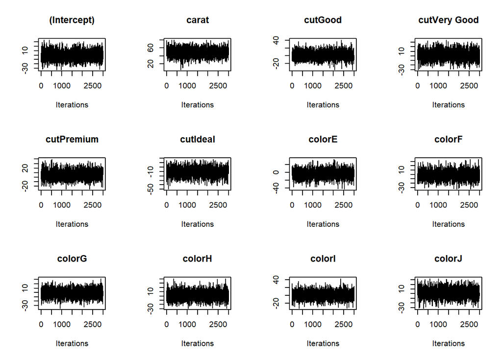

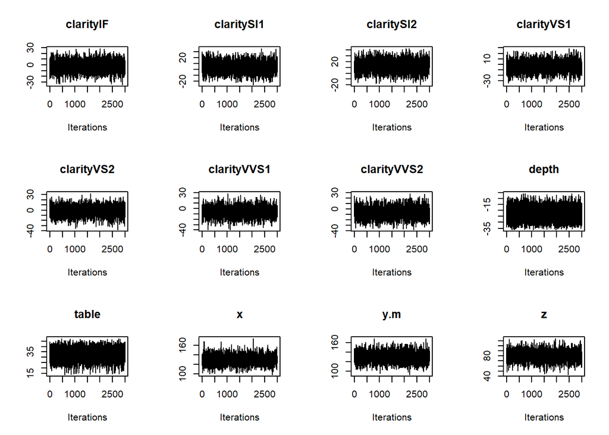

```r
par(mfrow=c(3, 4))
for(i in 1:p){
coda::traceplot(mcmc(model2_run$BUGSoutput$sims.list$b[,i]), main=colnames(X_train)[i])
}
```

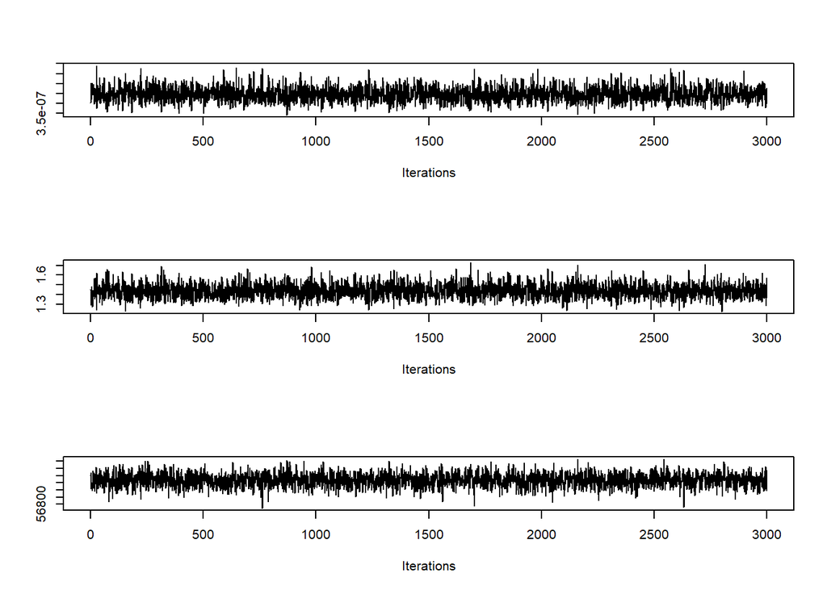

```r
par(mfrow=c(3,1))
traceplot(mcmc(model2_run$BUGSoutput$sims.list$tau))
traceplot(mcmc(model2_run$BUGSoutput$sims.list$k))
traceplot(mcmc(model2_run$BUGSoutput$sims.list$deviance))
```

#### Auto-Correlation Plot

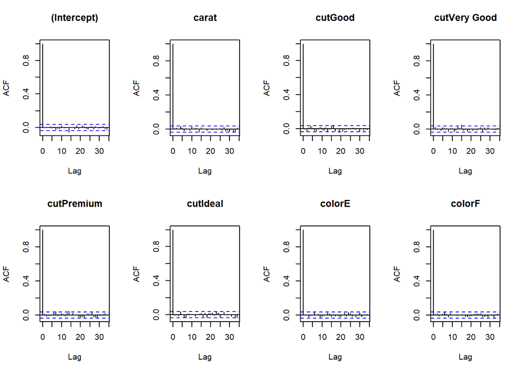

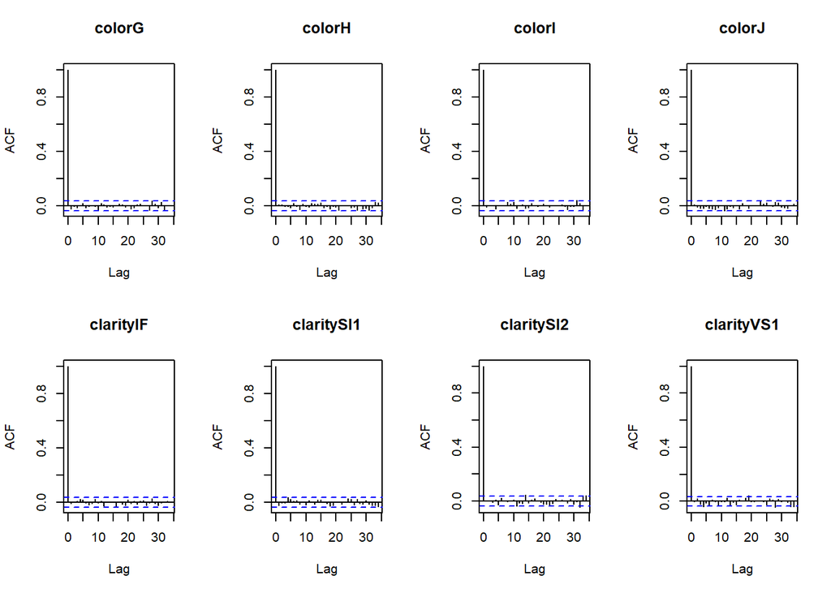

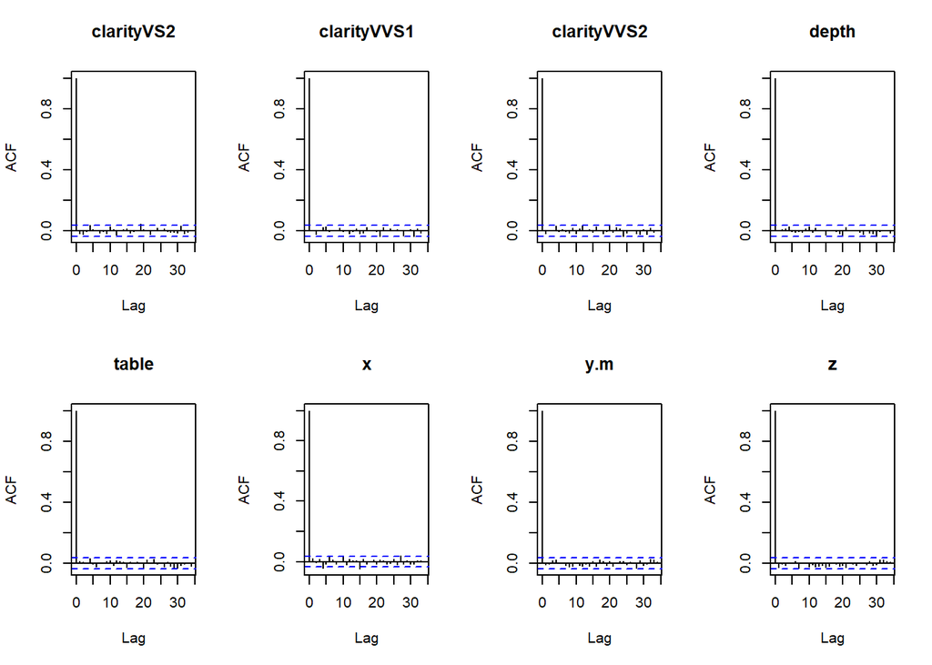

```r
par(mfrow=c(2,4))
for(i in 1:p){
acf(model2_run$BUGSoutput$sims.list$b[,i], main=colnames(X_train)[i])
}
```

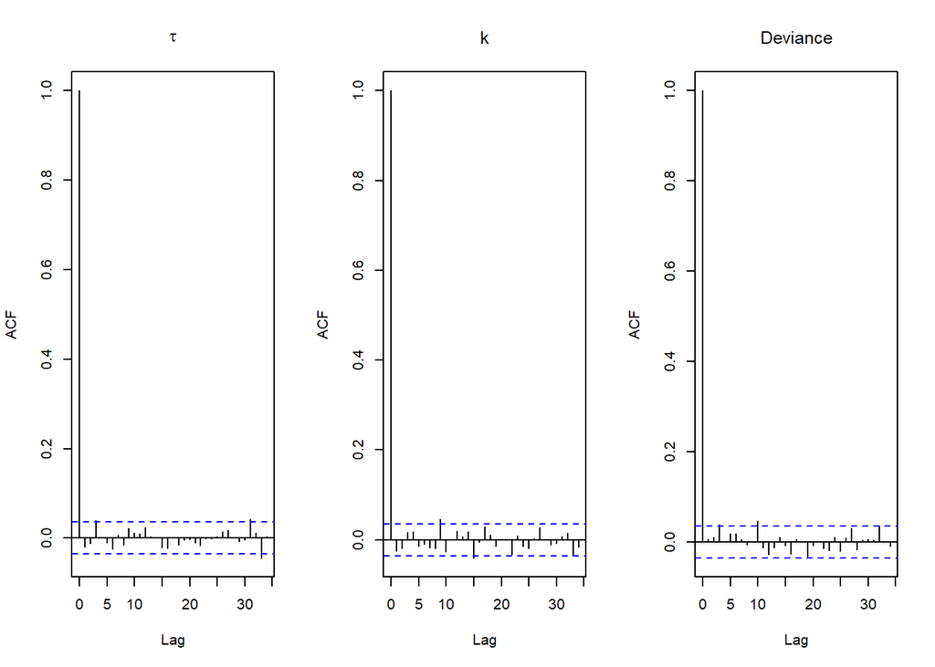

```r
par(mfrow=c(1,3))
acf(model2_run$BUGSoutput$sims.list$tau, main=expression(tau))
acf(model2_run$BUGSoutput$sims.list$k, main=expression(k))
acf(model2_run$BUGSoutput$sims.list$deviance, main=expression(Deviance))
```

#### Effective Sample Size

```r
for(i in 1:p){
  cat(colnames(X_train)[i],": ",coda::effectiveSize(mcmc(model2_run$BUGSoutput$sims.list$b[,i])), sep="", end="\n")
}
```

```
## (Intercept): 3000
## carat: 3000
## cutGood: 3000
## cutVery Good: 3000
## cutPremium: 3000
## cutIdeal: 3000
## colorE: 3000
## colorF: 3000
## colorG: 3000
## colorH: 3000
## colorI: 3000
## colorJ: 3000
## clarityIF: 3000
## claritySI1: 3000
## claritySI2: 3000
## clarityVS1: 3000
## clarityVS2: 3000
## clarityVVS1: 3000
## clarityVVS2: 3000
## depth: 3000
## table: 3000
## x: 3076.154
## y.m: 3000
## z: 3160.268
```

```r
cat(colnames(X_train)[i],": ",coda::effectiveSize(mcmc(model2_run$BUGSoutput$sims.list$tau)))
```

```
## z :  2960.182
```

```r
cat(colnames(X_train)[i],": ",coda::effectiveSize(mcmc(model2_run$BUGSoutput$sims.list$k)))
```

```
## z :  3000
```

#### Geweke Test

```r
for(i in 1:p){
cat('Geweke test for ',colnames(X_train)[i],':',coda::geweke.diag(
model2_run$BUGSoutput$sims.list$b[,i])$z,end="\n")
}
```

```
## Geweke test for  (Intercept) : 2.671456
## Geweke test for  carat : 1.385375
## Geweke test for  cutGood : 1.000918
## Geweke test for  cutVery Good : 0.1397227
## Geweke test for  cutPremium : -0.9939059
## Geweke test for  cutIdeal : 0.20345
## Geweke test for  colorE : -1.088541
## Geweke test for  colorF : 0.9242661
## Geweke test for  colorG : -1.730148
## Geweke test for  colorH : -0.05912712
## Geweke test for  colorI : -1.309157
## Geweke test for  colorJ : 0.5172347
## Geweke test for  clarityIF : -0.5117547
## Geweke test for  claritySI1 : 1.352052
## Geweke test for  claritySI2 : -1.687405
## Geweke test for  clarityVS1 : -1.275791
## Geweke test for  clarityVS2 : 0.2543577
## Geweke test for  clarityVVS1 : -0.2442372
## Geweke test for  clarityVVS2 : -0.4417202
## Geweke test for  depth : -0.081409
## Geweke test for  table : -0.1023763
## Geweke test for  x : 0.4564869
## Geweke test for  y.m : -1.257036
## Geweke test for  z : -0.6957297
```

```r
cat('Geweke test for n0:',coda::geweke.diag(
model2_run$BUGSoutput$sims.list$tau)$z)
```

```
## Geweke test for n0: 2.039605
```

```r
cat('Geweke test for n0:',coda::geweke.diag(
model2_run$BUGSoutput$sims.list$k)$z)
```

```
## Geweke test for n0: -1.205112
```

## Parameters Analysis

### Significant Variables and Credible Intervals

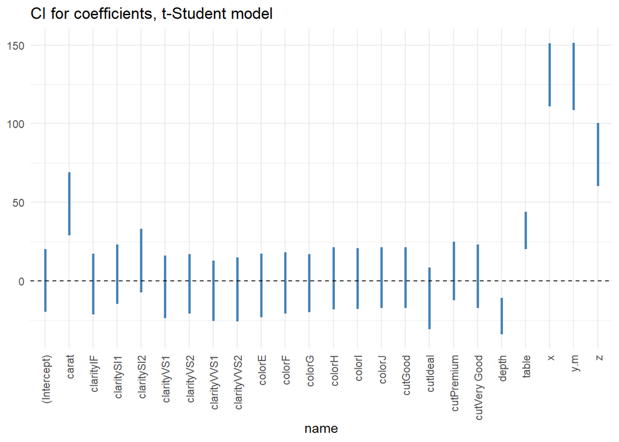

```r
b2_df <- as.data.frame(model2_run$BUGSoutput$sims.list$b)
names(b2_df) <- colnames(X_train)
b2_long <- pivot_longer(b2_df, cols = 1:24) %>%
  group_by(name) %>%
  summarise(q025 = quantile(value, 0.025), q975 = quantile(value, 0.975)) %>%
  ungroup()

ggplot(b2_long, aes(x = name, ymin = q025, ymax = q975)) +
  geom_linerange(size = 1, color = "steelblue") +
  geom_hline(yintercept = 0, linetype = 2) + theme_minimal() +
  theme(axis.text.x = element_text(angle = 90, vjust = 0.5, hjust=1)) +
  ggtitle("CI for coefficients, t-Student model")
```

```r
resu = as.matrix(colMeans(model2_run$BUGSoutput$sims.list$b),nrow=25)
resu = rbind(resu,colMeans(model2_run$BUGSoutput$sims.list$tau))
rownames(resu) = c(colnames(X_train),"Tau")
colnames(resu) = "Posterior Expectation"

res = t(apply(model2_run$BUGSoutput$sims.list$b,2,quantile,
prob=c(.025,.975)))
res = rbind(res,t(quantile(model2_run$BUGSoutput$sims.list$tau,
prob=c(.025,.975))))
rownames(res) = c(colnames(X_train),"Tau")
colnames(res) = c("2.5 % Quantile","97.5 % Quantile")
knitr::kable(cbind(res,resu), align = "ccc")
```

|  | 2.5 % Quantile | 97.5 % Quantile | Posterior Expectation |
| --- | --- | --- | --- |
| (Intercept) | -19.5636495 | 20.1211934 | -0.0623434 |
| carat | 28.8589306 | 69.0366534 | 49.1309675 |
| cutGood | -17.3128249 | 21.4653128 | 1.8771222 |
| cutVery Good | -17.1691390 | 23.0935374 | 2.3870017 |
| cutPremium | -12.2125999 | 24.8782552 | 5.5185152 |
| cutIdeal | -30.6121096 | 8.5942067 | -11.2492167 |
| colorE | -23.0989576 | 17.2265158 | -2.6945445 |
| colorF | -20.6138892 | 18.1314649 | -0.8188580 |
| colorG | -19.7541213 | 17.1239922 | -1.2086137 |
| colorH | -18.0861521 | 21.4912786 | 1.8576410 |
| colorI | -17.9447717 | 20.7991917 | 1.1723126 |
| colorJ | -17.3284741 | 21.5383286 | 2.0975906 |
| clarityIF | -21.4231599 | 17.2187806 | -2.0036454 |
| claritySI1 | -14.5807372 | 23.2434010 | 4.4004950 |
| claritySI2 | -7.3158440 | 33.2206968 | 12.8086672 |
| clarityVS1 | -23.6343526 | 16.0450898 | -3.1443542 |
| clarityVS2 | -20.7959904 | 17.1495199 | -1.6903368 |
| clarityVVS1 | -25.2918272 | 12.9837953 | -5.8479932 |
| clarityVVS2 | -25.6071090 | 14.9231228 | -5.3633179 |
| depth | -33.8547787 | -10.6802616 | -23.0018794 |
| table | 20.2191825 | 43.8641186 | 33.0806911 |
| x | 111.0613253 | 150.9068658 | 130.4510397 |
| y.m | 108.5038981 | 151.2211881 | 129.4695357 |
| z | 60.1985612 | 100.3481301 | 80.6333117 |
| Tau | 0.0000004 | 0.0000005 | 0.0000004 |

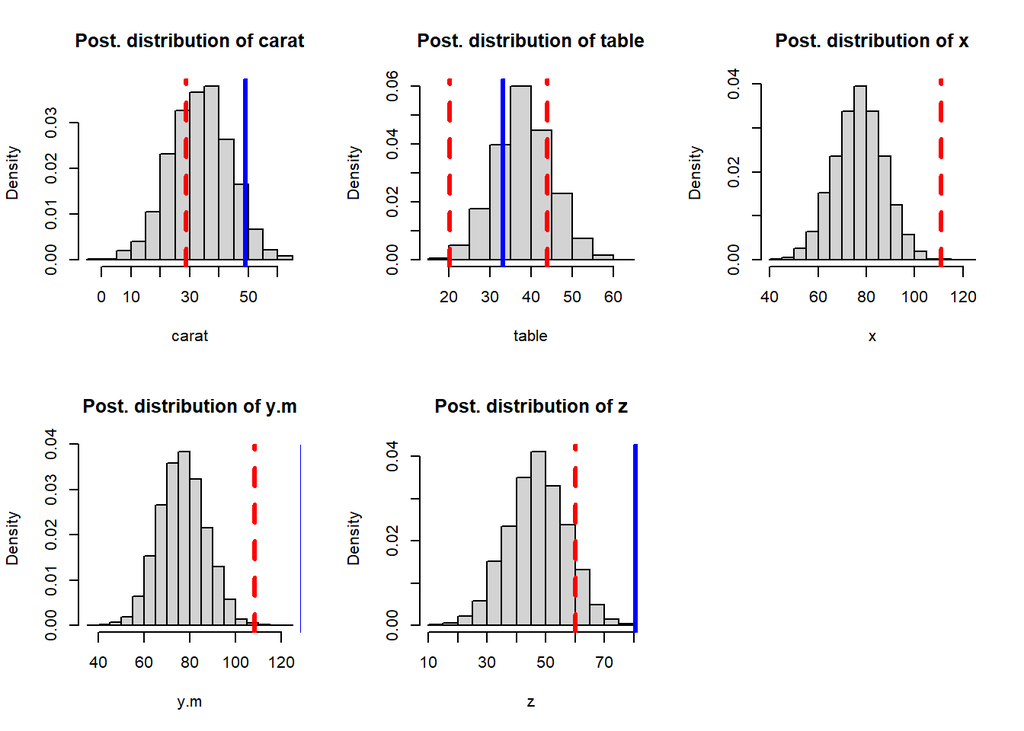

```r
par(mfrow=c(2,3))
for(i in c(2, 21, 22, 23, 24)){
hist(model1_run$BUGSoutput$sims.list$b[,i],
main=paste("Post. distribution of", rownames(res)[i]),
xlab = rownames(res)[i],cex=0.8, prob = TRUE)
abline(v=res[i,1], col="red",lty=2, lwd=3)
abline(v=res[i,2], col="red",lty=2, lwd=3)
abline(v=resu[i,1], col="blue", lwd=3)
}
```